# Week5_Tasks

# R 語言與資料科學導論作業 (W5)

一般系 b96001001 未命名

## Data Analysis (95%)

### 請使用R的內建資料`esoph`當作練習用的資料。

#### 一、請先瞭解一下這個資料的內容（`help(esoph)`）。 (15%)

- 請用summary()列出這筆資料的簡單描述統計。(10%)
- 請找出這個資料集共有幾列資料。 (5%)

```r
# your code goes here
summary(esoph)
```

```
##    agegp          alcgp         tobgp        ncases         ncontrols
##  25-34:15   0-39g/day:23   0-9g/day:24   Min.   : 0.000   Min.   : 1.00
##  35-44:15   40-79    :23   10-19   :24   1st Qu.: 0.000   1st Qu.: 3.00
##  45-54:16   80-119   :21   20-29   :20   Median : 1.000   Median : 6.00
##  55-64:16   120+     :21   30+     :20   Mean   : 2.273   Mean   :11.08
##  65-74:15                                3rd Qu.: 4.000   3rd Qu.:14.00
##  75+  :11                                Max.   :17.000   Max.   :60.00
```

```r
c(組數 = length(esoph[[1]]))
```

```
## 組數
##   88
```

#### 二、資料作圖 (20%)

- 請對此資料集做一張圖，任何圖（散佈圖、直方圖、或課堂上看到的散佈矩陣圖）都可以。

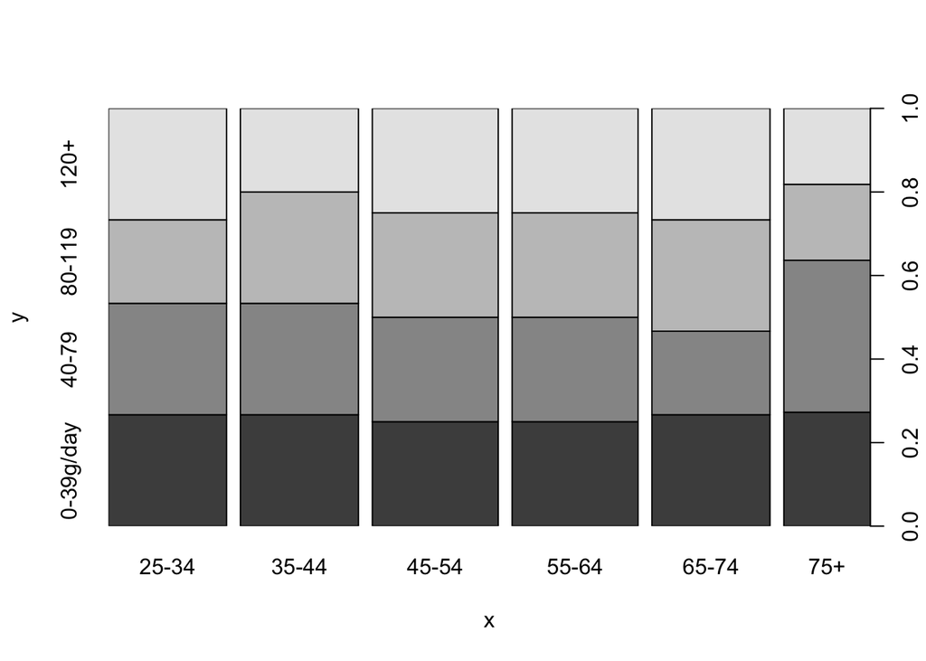

#### 三、請做出一個各年齡組的摘要表。 (30%)

- 請製作出如下摘要表，呈現各年齡組的個案數和控制組數總和。
- 這張摘要表應有6列，每列分別是一個年齡組 (10%)。在年齡組（agegp）變項中，請計算每組的sum_ncases， 代表在各年齡組中，所有ncases的總和 (10%)；以及sum_ncontrols，代表在各年齡組中，所有ncontrols的總和 (10%)。

最後的結果會類似這樣：

```
  agegp sum_ncases sum_ncontrols
  <ord>      <dbl>         <dbl>
1 25-34
2 35-44
3 45-54          (values)
4 55-64
5 65-74
6   75+
```

```r
# your code goes here
library(magrittr)
library(dplyr)
esoph %>%
  select(agegp, ncases, ncontrols) %>%
  group_by(agegp) %>%
  summarise(sum_ncases = sum(ncases), sum_ncontrols = sum(ncontrols)) %>%
  arrange((agegp))
```

```
## # A tibble: 6 x 3
##   agegp sum_ncases sum_ncontrols
##   <ord>      <dbl>         <dbl>
## 1 25-34          1           116
## 2 35-44          9           199
## 3 45-54         46           213
## 4 55-64         76           242
## 5 65-74         55           161
## 6   75+         13            44
```

#### 第四、不同酒精使用程度的摘要表。(30%)

- 請製作出如下的摘要表。該摘要表呈現的是25-34和45-54兩個年齡組，他們在不同酒精使用程度中的個案數和控 制組數總和。
- 您需要將25-34和45-54兩個年齡組的資料取出(10%)，並按照這兩個年齡組個別的酒精使用程度將資料分組(10%)。 最後計算個案數和控制組數的總和(10%)

最後的結果會類似這樣：

```
  agegp     alcgp ncases ncontrols
  <ord>     <ord>  <dbl>     <dbl>
1 25-34 0-39g/day
2 25-34     40-79
3 25-34    80-119
4 25-34      120+     (values)
5 45-54 0-39g/day
6 45-54     40-79
7 45-54    80-119
8 45-54      120+
```

```r
# your code goes here
library(magrittr)
library(dplyr)
esoph %>%
  filter(agegp == "25-34" | agegp == "45-54") %>%
  select(agegp, ncases, ncontrols, alcgp) %>%
  group_by(agegp, alcgp) %>%
  summarise(ncases = sum(ncases), ncontrols = sum(ncontrols)) %>%
  arrange((agegp))
```

```
## # A tibble: 8 x 4
## # Groups:   agegp [2]
##   agegp     alcgp ncases ncontrols
##   <ord>     <ord>  <dbl>     <dbl>
## 1 25-34 0-39g/day      0        61
## 2 25-34     40-79      0        45
## 3 25-34    80-119      0         5
## 4 25-34      120+      1         5
## 5 45-54 0-39g/day      1        78
## 6 45-54     40-79     20        81
## 7 45-54    80-119     12        39
## 8 45-54      120+     13        15
```

## 進階選答題

[台北YouBike 開放資料](https://goo.gl/KLxuhf)是一個很常在資料科學專案應用或教學的例子。這個資料就在我們身邊，我們都接觸過他，甚至才剛剛貢獻過一點資料。這個作業請你試著接觸YouBike資料，看看裡面有什麼訊息。

### A. 把YouBike資料轉為data.frame (10%)

請你先到[台北YouBike 開放資料](https://goo.gl/KLxuhf)看一下資料描述。其中提到現在的介接網址是http://data.taipei/youbike。你可以直接在R裡面把這個檔案下載下來；或者手動把它下載下來後，把JSON格式換成R的data.frame。

> Update (20171015):

> 因YouBike開放資料系統維護。若無法從介接網址取得資料，請從此[連結](https://goo.gl/3HqWBa)下載201710132314的JSON資料。  
> 資料格式說明：

> ```
> sno：站點代號、sna：場站名稱(中文)、 tot：場站總停車格、
> sbi：場站目前車輛數量、 sarea：場站區域(中文)、
> mday：資料更新時間、 lat：緯度、 lng：經度、 ar：地(中文)、
> sareaen：場站區域(英文)、 snaen：場站名稱(英文)、 aren：地址(英文)、
> bemp：空位數量、 act：全站禁用狀態
> ```

提示：

```

```r
# your code goes here.
# please display the data frame with proper format.
library(jsonlite)
library(RCurl)
#UBike_Data <- fromJSON("/Volumes/BaseQi/W5/3HqWBa.json")
UBike_Data <- fromJSON("http://data.taipei/youbike") #讀資料
UBF <- UBike_Data$retVal #讀值
json_file <- lapply(UBF, function(x) {
  x[sapply(x, is.null)] <- NA
  unlist(x)
})  #收起來
#json_file <- data.frame(lapply(json_file, as.character), stringsAsFactors=FALSE)
UBdata <- do.call("rbind",json_file) #壓起來
UBF <- as.data.frame(UBdata) #換型態
library(dplyr)
UBF %>% mutate_if(is.factor, as.character) -> UBF #因為data.frame裡面都是factor, 所以先換成char
UBF$sno <- as.integer(UBF$sno)
UBF$tot <- as.integer(UBF$tot)
UBF$sbi <- as.integer(UBF$sbi)
UBF$lat <- as.double(UBF$lat)
UBF$lng <- as.double(UBF$lng)
UBF$act <- as.integer(UBF$act) #各個column換成該要有的型態
UBF
```

```
##     sno                          sna tot sbi  sarea           mday
## 1     1        捷運市政府站(3號出口) 180 141 信義區 20171017134416
## 2     2    捷運國父紀念館站(2號出口)  48  16 大安區 20171017134422
## 3     3                   台北市政府  40  23 信義區 20171017134413
## 4     4                     市民廣場  60  23 信義區 20171017134434
## 5     5                     興雅國中  60  33 信義區 20171017134434
## 6     6                     世貿二館  80   0 信義區 20170908084345
## 7     7            信義廣場(台北101)  80  28 信義區 20171017134424
## 8     8                     世貿三館  60  35 信義區 20171017134432
## 9     9                       松德站  40  12 信義區 20171017134423
## 10   10           台北市災害應變中心  54  14 信義區 20171017134440
## 11   11                       三張犁  66  27 信義區 20171017134435
## 12   12                 臺北醫學大學  48  34 信義區 20171017134442
## 13   13                     福德公園  58  25 信義區 20171017134425
## 14   14                     榮星花園  32  12 中山區 20171017134422
```

[output cut: 2277 more lines]

提示：

- 資料經過A的處理後，應該已經變成一個乾淨的data frame（或tibble），您在這步僅需把幾個變項選取出來，群組、平均、排序即可。記得YouBike資料裡有一欄是全站禁用狀態（act），我們只關心運作中的站點。

```r
# your code goes here.
# please display the data frame with proper format.
library("magrittr") #pipe
library("dplyr")
UBF %>%
  filter(act == 1) %>%
  select(tot, sbi, sarea) %>%
  group_by(sarea) %>%
  summarise(空位數 = sum(tot - sbi), 平均停車格 = mean(tot), 目前車輛數 = sum(sbi)) %>%
  arrange(desc(空位數))
```

```
## # A tibble: 12 x 4
##     sarea 空位數 平均停車格 目前車輛數
##     <chr>  <int>      <dbl>      <int>
##  1 大安區   1167   42.86957        805
##  2 中山區    968   40.48889        854
##  3 信義區    796   47.47059        818
##  4 中正區    787   42.72727        623
##  5 內湖區    762   38.16216        650
##  6 北投區    723   43.50000        495
##  7 士林區    700   39.45455        602
##  8 松山區    649   38.51613        545
##  9 文山區    549   38.40000        411
## 10 大同區    497   36.76190        275
## 11 萬華區    493   38.72727        359
## 12 南港區    392   36.63636        414
```

### C. 請篩選出空位率最高的5％站點，並且按照他們的空位率（從大到小）排序。(5%)

提示：

- 和上一題相似，但你需要自己計算一個新的欄位（空位率），並且要找出前5%的站點。選出前5%的資料至少有兩種可能的方法：（1）找出5%的空位率是多少，用該值去過濾資料；（2）先把資料按空位率排序之後，只取前5%的資料。兩個想法都是合理的，只是結果可能會些許不同。

```r
# your code goes here.
# please display the data frame with proper format.
library("magrittr")
library("dplyr")
a <- UBF %>%
    filter(act == 1) %>%
    select(tot, sbi, sna, lng, lat) %>%
    group_by(sna) %>%
    summarise(空位數 = (tot - sbi), 停車格 = (tot), 目前車輛數 = (sbi), 空位率 = 空位數/停車格) %>%
    arrange(desc(空位率))
head(a,19)
```

```
## # A tibble: 19 x 5
##                        sna 空位數 停車格 目前車輛數    空位率
##                      <chr>  <int>  <int>      <int>     <dbl>
##  1            民生活動中心     32     32          0 1.0000000
##  2     捷運雙連站(2號出口)     41     42          1 0.9761905
##  3            重慶酒泉街口     27     28          1 0.9642857
##  4                豐年公園     28     30          2 0.9333333
##  5            仁愛延吉街口     31     34          3 0.9117647
##  6            市民太原路口     31     34          3 0.9117647
##  7              大稻埕公園     34     38          4 0.8947368
##  8            捷運六張犁站     34     38          4 0.8947368
##  9        迪化休閒運動公園     25     28          3 0.8928571
## 10          蔣渭水紀念公園     32     36          4 0.8888889
## 11 捷運忠孝復興站(2號出口)     48     54          6 0.8888889
## 12     捷運港墘站(2號出口)     44     50          6 0.8800000
## 13                麗山高中     35     40          5 0.8750000
## 14                林森公園     28     32          4 0.8750000
## 15                社正公園     35     40          5 0.8750000
## 16                  圓環站     28     32          4 0.8750000
## 17            中華桂林路口     28     32          4 0.8750000
## 18            中山青島路口     33     38          5 0.8684211
## 19                瑠公公園     26     30          4 0.8666667
```

```r
a
```

```
## # A tibble: 377 x 5
##                    sna 空位數 停車格 目前車輛數    空位率
##                  <chr>  <int>  <int>      <int>     <dbl>
##  1        民生活動中心     32     32          0 1.0000000
##  2 捷運雙連站(2號出口)     41     42          1 0.9761905
##  3        重慶酒泉街口     27     28          1 0.9642857
##  4            豐年公園     28     30          2 0.9333333
##  5        仁愛延吉街口     31     34          3 0.9117647
##  6        市民太原路口     31     34          3 0.9117647
##  7          大稻埕公園     34     38          4 0.8947368
##  8        捷運六張犁站     34     38          4 0.8947368
##  9    迪化休閒運動公園     25     28          3 0.8928571
## 10      蔣渭水紀念公園     32     36          4 0.8888889
## # ... with 367 more rows
```

### D. 請把站點的位置畫在一張地圖上，並且同時呈現每個站點的空位率。(5%)

### 提示：

```r
# your code goes here.
library("ggmap") # 畫圖
```

[figure not shown]

```r
library("magrittr")
library("dplyr")
a <- UBF %>%
    filter(act == 1) %>%
    select(tot, sbi, sna, lng, lat) %>%
    group_by(sna) %>%
    summarise(空位數 = (tot-sbi), 停車格 = (tot), 目前車輛數 = (sbi), Vacancy = 空位數/停車格, lat = lat, lng = lng) %>%
    arrange(desc(Vacancy))

map <- get_map(location = c(lon = 121.55, lon = 25.07), zoom = 13, language = "zh-TW", maptype = "roadmap") #設定圖
ggmap(map, darken = c(0.1, "white")) + geom_point(aes(x = lng, y = lat, col = Vacancy), data = a) +
  geom_point() +
    scale_colour_gradientn(colours=rainbow(3)) #彩色bar
```